# Shark Attacks

### Data Cleaning and Manipulation with Pandas

## Libraries

```python
import re
import pandas as pd
import datetime as dt
import matplotlib.pyplot as plt
```

## Code

### Paso 1 - Carga

Para empezar, cargamos el documento y hacemos un primer análisis

```python
attacks = pd.read_csv('./attacks.csv', encoding='latin-1', parse_dates=True)
```

```python
attacks.head()
```

|  | Case Number | Date | Year | Type | Country | Area | Location | Activity | Name | Sex | Age | Injury | Fatal (Y/N) | Time | Species | Investigator or Source | pdf | href formula | href | Case Number.1 | Case Number.2 | original order | Unnamed: 22 | Unnamed: 23 |
| --- | --- | --- | --- | --- | --- | --- | --- | --- | --- | --- | --- | --- | --- | --- | --- | --- | --- | --- | --- | --- | --- | --- | --- | --- |
| 0 | 2018.06.25 | 25-Jun-2018 | 2018.0 | Boating | USA | California | Oceanside, San Diego County | Paddling | Julie Wolfe | F | 57 | No injury to occupant, outrigger canoe and pad... | N | 18h00 | White shark | R. Collier, GSAF | 2018.06.25-Wolfe.pdf | http://sharkattackfile.net/spreadsheets/pdf_di... | http://sharkattackfile.net/spreadsheets/pdf_di... | 2018.06.25 | 2018.06.25 | 6303.0 | NaN | NaN |
| 1 | 2018.06.18 | 18-Jun-2018 | 2018.0 | Unprovoked | USA | Georgia | St. Simon Island, Glynn County | Standing | Adyson McNeely | F | 11 | Minor injury to left thigh | N | 14h00 -15h00 | NaN | K.McMurray, TrackingSharks.com | 2018.06.18-McNeely.pdf | http://sharkattackfile.net/spreadsheets/pdf_di... | http://sharkattackfile.net/spreadsheets/pdf_di... | 2018.06.18 | 2018.06.18 | 6302.0 | NaN | NaN |
| 2 | 2018.06.09 | 09-Jun-2018 | 2018.0 | Invalid | USA | Hawaii | Habush, Oahu | Surfing | John Denges | M | 48 | Injury to left lower leg from surfboard skeg | N | 07h45 | NaN | K.McMurray, TrackingSharks.com | 2018.06.09-Denges.pdf | http://sharkattackfile.net/spreadsheets/pdf_di... | http://sharkattackfile.net/spreadsheets/pdf_di... | 2018.06.09 | 2018.06.09 | 6301.0 | NaN | NaN |
| 3 | 2018.06.08 | 08-Jun-2018 | 2018.0 | Unprovoked | AUSTRALIA | New South Wales | Arrawarra Headland | Surfing | male | M | NaN | Minor injury to lower leg | N | NaN | 2 m shark | B. Myatt, GSAF | 2018.06.08-Arrawarra.pdf | http://sharkattackfile.net/spreadsheets/pdf_di... | http://sharkattackfile.net/spreadsheets/pdf_di... | 2018.06.08 | 2018.06.08 | 6300.0 | NaN | NaN |
| 4 | 2018.06.04 | 04-Jun-2018 | 2018.0 | Provoked | MEXICO | Colima | La Ticla | Free diving | Gustavo Ramos | M | NaN | Lacerations to leg & hand shark PROVOKED INCIDENT | N | NaN | Tiger shark, 3m | A .Kipper | 2018.06.04-Ramos.pdf | http://sharkattackfile.net/spreadsheets/pdf_di... | http://sharkattackfile.net/spreadsheets/pdf_di... | 2018.06.04 | 2018.06.04 | 6299.0 | NaN | NaN |

```python
attacks.info()
```

```
<class 'pandas.core.frame.DataFrame'>
RangeIndex: 25723 entries, 0 to 25722
Data columns (total 24 columns):
 #   Column                  Non-Null Count  Dtype
---  ------                  --------------  -----
 0   Case Number             8702 non-null   object
 1   Date                    6302 non-null   object
 2   Year                    6300 non-null   float64
 3   Type                    6298 non-null   object
 4   Country                 6252 non-null   object
 5   Area                    5847 non-null   object
 6   Location                5762 non-null   object
 7   Activity                5758 non-null   object
 8   Name                    6092 non-null   object
 9   Sex                     5737 non-null   object
```

[output cut: 16 more lines]

### Paso 2 - Primera limpieza

Se eliminan:

- Espacios sobrantes de los títulos de las columnas
- Filas duplicadas
- Columnas con todo valores nulos
- Filas con 2 o más columnas las cuales tengan todo valores nulos

```python
attacks.rename(columns=lambda x: re.sub('^\s*|\s*$','',x), inplace=True)
attacks.drop_duplicates(inplace=True)
attacks.dropna(axis=1, how='all', inplace=True)
attacks.dropna(axis=0, how='all', thresh=2, inplace=True)
```

### Paso 3 - Análisis por columnas

#### 'Year'

Los datos de años anteriores a 1700 pueden no ser del todo fiables, por lo que decido eliminarlos del DataFrame. Para ello:

- Relleno los valores nulos con 0 y los convierto a `int`
- Elimino los años anteriores a 1700

```python
attacks['Year'] = attacks['Year'].fillna(0).astype('int')
attacks = attacks[attacks['Year'] >= 1700]
```

#### 'Case Number'

Esta columna contiene mayoritariamente fechas, pero con formato erróneo y algunas incorrectas.

Asumo que todas las columnas relativas a fechas han extraído las fechas de la columna `pdf`, por lo que esta debería contener la fecha correcta.

```python
# Extraer la fecha del fichero pdf

pdf_dates = re.compile('\d{4}\W\d{2}\W\d{2}')
```

```python
# Buscar fechas con ese formato en la columna de 'pdf'

pdf_dates_clean = attacks['pdf'].str.findall(pdf_dates).str.join('')
```

```python
# Reemplazar fechas correctas en la columna de 'Case Number'

attacks['Case Number'] = pdf_dates_clean
```

```python
# Reemplazar los .00 por .01

attacks['Case Number'].replace(to_replace='(\.+[0]{2})', value='.01', regex=True, inplace=True)
```

```python
# Convertir 'Case Number' a tipo fecha

attacks['Case Number'] = pd.to_datetime(attacks['Case Number'], errors='coerce').dt.strftime('%Y-%m-%d')
```

```python
# Para los valores nulos, igualar a la fecha de la columna 'Date'

attacks['Case Number'].fillna(attacks['Date'], inplace=True)
```

```python
# Eliminar la columna 'Date'

attacks.drop(axis=1, columns=['Date'], inplace=True)
```

```python
# Renombrar 'Case Number' por 'Date'

attacks.rename(columns={'Case Number': 'Date'}, inplace=True)
```

```python
attacks.head()
```

|  | Date | Year | Type | Country | Area | Location | Activity | Name | Sex | Age | Injury | Fatal (Y/N) | Time | Species | Investigator or Source | pdf | href formula | href | Case Number.1 | Case Number.2 | original order | Unnamed: 22 | Unnamed: 23 |
| --- | --- | --- | --- | --- | --- | --- | --- | --- | --- | --- | --- | --- | --- | --- | --- | --- | --- | --- | --- | --- | --- | --- | --- |
| 0 | 2018-06-25 | 2018 | Boating | USA | California | Oceanside, San Diego County | Paddling | Julie Wolfe | F | 57 | No injury to occupant, outrigger canoe and pad... | N | 18h00 | White shark | R. Collier, GSAF | 2018.06.25-Wolfe.pdf | http://sharkattackfile.net/spreadsheets/pdf_di... | http://sharkattackfile.net/spreadsheets/pdf_di... | 2018.06.25 | 2018.06.25 | 6303.0 | NaN | NaN |
| 1 | 2018-06-18 | 2018 | Unprovoked | USA | Georgia | St. Simon Island, Glynn County | Standing | Adyson McNeely | F | 11 | Minor injury to left thigh | N | 14h00 -15h00 | NaN | K.McMurray, TrackingSharks.com | 2018.06.18-McNeely.pdf | http://sharkattackfile.net/spreadsheets/pdf_di... | http://sharkattackfile.net/spreadsheets/pdf_di... | 2018.06.18 | 2018.06.18 | 6302.0 | NaN | NaN |
| 2 | 2018-06-09 | 2018 | Invalid | USA | Hawaii | Habush, Oahu | Surfing | John Denges | M | 48 | Injury to left lower leg from surfboard skeg | N | 07h45 | NaN | K.McMurray, TrackingSharks.com | 2018.06.09-Denges.pdf | http://sharkattackfile.net/spreadsheets/pdf_di... | http://sharkattackfile.net/spreadsheets/pdf_di... | 2018.06.09 | 2018.06.09 | 6301.0 | NaN | NaN |
| 3 | 2018-06-08 | 2018 | Unprovoked | AUSTRALIA | New South Wales | Arrawarra Headland | Surfing | male | M | NaN | Minor injury to lower leg | N | NaN | 2 m shark | B. Myatt, GSAF | 2018.06.08-Arrawarra.pdf | http://sharkattackfile.net/spreadsheets/pdf_di... | http://sharkattackfile.net/spreadsheets/pdf_di... | 2018.06.08 | 2018.06.08 | 6300.0 | NaN | NaN |
| 4 | 2018-06-04 | 2018 | Provoked | MEXICO | Colima | La Ticla | Free diving | Gustavo Ramos | M | NaN | Lacerations to leg & hand shark PROVOKED INCIDENT | N | NaN | Tiger shark, 3m | A .Kipper | 2018.06.04-Ramos.pdf | http://sharkattackfile.net/spreadsheets/pdf_di... | http://sharkattackfile.net/spreadsheets/pdf_di... | 2018.06.04 | 2018.06.04 | 6299.0 | NaN | NaN |

#### 'Type'

```python
attacks['Type'].replace(to_replace='Boat\w*', value='Boating', regex=True, inplace=True)
```

```python
attacks['Type'].replace(to_replace='Questionable', value='Unknown', regex=True, inplace=True)
```

```python
attacks['Type'].fillna('Unknown', inplace=True)
```

```python
attacks['Type'].value_counts()
```

```
Unprovoked      4474
Provoked         567
Invalid          543
Boating          339
Sea Disaster     233
Unknown            6
Name: Type, dtype: int64
```

#### 'Country'

```python
# Convertir todo a mayúsculas

attacks['Country'] = attacks['Country'].str.upper()
```

```python
# Eliminar espacios al principio y limpiar países

attacks['Country'].replace(to_replace='^\s*|\s*$|\s*\/\s*\w+|\?$|(?<=HELENA)(.*)|(?<=EMIRATES)(.*)|(.*)(?=AFRICA)|(.*)(?=MICRONESIA)|^MID\W+', value='', regex=True, inplace=True)
```

```python
attacks['Country'].replace(to_replace='ISLANDAS', value='ISLANDS', regex=True, inplace=True)
```

```python
attacks['Country'].replace(to_replace='MALDIVE ISLANDS', value='MALDIVES', regex=True, inplace=True)
```

```python
attacks['Country'].replace(to_replace='^ST\s+', value='ST. ', regex=True, inplace=True)
```

```python
attacks['Country'].fillna('UNKNOWN', inplace=True)
```

```python
attacks['Country'] = attacks['Country'].str.title()
```

```python
attacks['Country'].replace(to_replace='Usa', value='USA', regex=True, inplace=True)
```

```python
attacks['Country'].sort_values().unique()
```

```
array(['Admiralty Islands', 'Africa', 'Algeria', 'American Samoa',
       'Andaman Islands', 'Angola', 'Antigua', 'Argentina', 'Aruba',
       'Atlantic Ocean', 'Australia', 'Azores', 'Bahamas', 'Bangladesh',
       'Barbados', 'Bay Of Bengal', 'Belize', 'Bermuda', 'Brazil',
       'British Isles', 'British New Guinea', 'British Virgin Islands',
       'British West Indies', 'Burma', 'Canada', 'Cape Verde',
       'Caribbean Sea', 'Cayman Islands', 'Central Pacific', 'Ceylon',
       'Chile', 'China', 'Columbia', 'Comoros', 'Cook Islands',
       'Costa Rica', 'Crete', 'Croatia', 'Cuba', 'Curacao', 'Cyprus',
       'Diego Garcia', 'Dominican Republic', 'Ecuador', 'Egypt',
       'El Salvador', 'England', 'Equatorial Guinea', 'Falkland Islands',
       'Fiji', 'France', 'French Polynesia', 'Gabon', 'Georgia', 'Ghana',
       'Grand Cayman', 'Greece', 'Greenland', 'Grenada', 'Guam',
       'Guatemala', 'Guinea', 'Gulf Of Aden', 'Guyana', 'Haiti',
       'Honduras', 'Hong Kong', 'Iceland', 'India', 'Indian Ocean',
       'Indonesia', 'Iran', 'Iraq', 'Ireland', 'Israel', 'Italy',
       'Jamaica', 'Japan', 'Java', 'Johnston Island', 'Kenya', 'Kiribati',
       'Kuwait', 'Lebanon', 'Liberia', 'Libya', 'Madagascar', 'Malaysia',
       'Maldives', 'Malta', 'Marshall Islands', 'Martinique', 'Mauritius',
       'Mayotte', 'Mediterranean Sea', 'Mexico', 'Micronesia', 'Monaco',
       'Montenegro', 'Mozambique', 'Namibia', 'Netherlands Antilles',
       'Nevis', 'New Britain', 'New Caledonia', 'New Guinea',
       'New Zealand', 'Nicaragua', 'Nigeria', 'North Atlantic Ocean',
       'North Pacific Ocean', 'North Sea', 'Northern Arabian Sea',
       'Northern Mariana Islands', 'Norway', 'Ocean', 'Okinawa',
       'Pacific Ocean', 'Palau', 'Palestinian Territories', 'Panama',
       'Papua New Guinea', 'Paraguay', 'Persian Gulf', 'Peru',
       'Philippines', 'Portugal', 'Puerto Rico', 'Red Sea Ocean',
       'Reunion Island', 'Roatan', 'Russia', 'Samoa', 'San Domingo',
       'Saudi Arabia', 'Scotland', 'Senegal', 'Seychelles',
       'Sierra Leone', 'Singapore', 'Slovenia', 'Solomon Islands',
       'Somalia', 'South Atlantic Ocean', 'South China Sea',
       'South Korea', 'South Pacific Ocean', 'Southwest Pacific Ocean',
       'Spain', 'Sri Lanka', 'St. Helena', 'St. Martin', 'Sudan',
       'Sweden', 'Syria', 'Taiwan', 'Tanzania', 'Tasman Sea', 'Thailand',
       'The Balkans', 'Tobago', 'Tonga', 'Trinidad & Tobago', 'Tunisia',
       'Turkey', 'Turks & Caicos', 'Tuvalu', 'USA',
       'United Arab Emirates', 'United Kingdom', 'Unknown', 'Uruguay',
       'Vanuatu', 'Venezuela', 'Vietnam', 'West Indies', 'Western Samoa',
       'Yemen'], dtype=object)
```

#### 'Area' y 'Location'

Al tener muchos datos sucios, he decidido mantenerlas en el DataFrame pero no limpiarlas.

#### 'Activity'

```python
attacks['Activity'].fillna('Unknown', inplace=True)
```

```python
attacks['Activity'].replace(to_replace='^\s*|\s{2,}|\s*$', value='', regex=True, inplace=True)
```

```python
# Decido centrarme en las 20 actividades con más casos de ataques de tiburones.
# Considero que solo esas son las relevantes, todo el resto son desconocidas.

attacks['Activity'].value_counts().nlargest(20).index.to_list()
```

[output not shown]

```python
attacks['Activity'] = attacks['Activity'].apply(lambda x: x if x in activities else 'Unknown')
```

```python
attacks['Activity'].value_counts()
```

```
Unknown            2481
Surfing             975
Swimming            898
Fishing             436
Spearfishing        335
Bathing             162
Wading              146
Diving              118
Standing             99
Scuba Diving         90
Snorkeling           88
Body Boarding        65
Body Surfing         50
Boogie Boarding      45
Kayaking             35
Fell Overboard       33
Treading Water       32
Free Diving          28
Pearl Diving         27
Windsurfing          19
Name: Activity, dtype: int64
```

#### 'Species'

```python
attacks['Species'].replace(to_replace='^\s*|\s{2,}|\s*$', value='', regex=True, inplace=True)
attacks['Species'].fillna('Unknown', inplace=True)
```

```python
clean_species = attacks['Species'].str.findall('((?:\w{3,} )?[s|S]hark)').str.join('').str.title()
```

```python
# Creo una nueva columna con el formato correcto, elimino la antigua columna 'Species' y renombro la nueva

attacks.insert(loc=14, column='Clean Species', value=clean_species)
attacks.drop(axis=1, columns=['Species'], inplace=True)
attacks.rename(columns={'Clean Species': 'Species'}, inplace=True)
```

```python
attacks['Species'].fillna('Unknown', inplace=True)
```

#### 'Sex'

```python
attacks['Sex'].value_counts()
```

```
M      4977
F       624
N         2
M         2
lli       1
.         1
Name: Sex, dtype: int64
```

```python
attacks['Sex'].replace(to_replace='^\s*|\s*$', value='', regex=True, inplace=True)
attacks['Sex'].replace(to_replace='N', value='M', regex=True, inplace=True)
attacks['Sex'].replace(to_replace='^\.|lli$', value='Unknown', regex=True, inplace=True)
attacks['Sex'].fillna('Unknown', inplace=True)
```

#### 'Injury'

No es relevante para el análisis. La eliminamos.

#### 'Fatal (Y/N)'

```python
attacks['Fatal (Y/N)'].value_counts()
```

```
N          4227
Y          1324
UNKNOWN      64
 N            7
M             1
N             1
2017          1
y             1
Name: Fatal (Y/N), dtype: int64
```

```python
attacks['Fatal (Y/N)'] = attacks['Fatal (Y/N)'].str.upper()
attacks['Fatal (Y/N)'].replace(to_replace='^\s*|\s{2,}|\s*$', value='', regex=True, inplace=True)
attacks['Fatal (Y/N)'].replace(to_replace='^M$', value='N', regex=True, inplace=True)
attacks['Fatal (Y/N)'].replace(to_replace='^\d+$', value='Unknown', regex=True, inplace=True)
attacks['Fatal (Y/N)'].fillna('Unknown', inplace=True)
attacks['Fatal (Y/N)'] = attacks['Fatal (Y/N)'].str.title()
```

### Paso 4 - Eliminar datos innecesarios

Tras hacer la limpieza, decido:

- Eliminar las columnas a las que les falta el 60% de los datos
- Eliminar las últimas 7 columnas

```python
attacks.dropna(axis=1, thresh=attacks.shape[0]*0.6, inplace=True)
attacks.drop(attacks.columns[-7:], axis=1, inplace=True)
```

```python
print(attacks.columns)
print(len(attacks.columns))
```

```
Index(['Date', 'Year', 'Type', 'Country', 'Area', 'Location', 'Activity',
       'Sex', 'Fatal (Y/N)', 'Species'],
      dtype='object')
10
```

### Paso 5 - Index

Ya como último paso, decido setear el país como index para poder basar mi análisis en esta información

```python
attacks.set_index('Country', inplace=True)
attacks.head(11)
```

| Country | Date | Year | Type | Area | Location | Activity | Sex | Fatal (Y/N) | Species |
| --- | --- | --- | --- | --- | --- | --- | --- | --- | --- |
| USA | 2018-06-25 | 2018 | Boating | California | Oceanside, San Diego County | Unknown | F | N | White Shark |
| USA | 2018-06-18 | 2018 | Unprovoked | Georgia | St. Simon Island, Glynn County | Standing | F | N |  |
| USA | 2018-06-09 | 2018 | Invalid | Hawaii | Habush, Oahu | Surfing | M | N |  |
| Australia | 2018-06-08 | 2018 | Unprovoked | New South Wales | Arrawarra Headland | Surfing | M | N | Shark |
| Mexico | 2018-06-04 | 2018 | Provoked | Colima | La Ticla | Free Diving | M | N | Tiger Shark |
| Australia | 2018-06-03 | 2018 | Unprovoked | New South Wales | Flat Rock, Ballina | Unknown | M | N |  |
| Brazil | 2018-06-03 | 2018 | Unprovoked | Pernambuco | Piedade Beach, Recife | Swimming | M | Y | Tiger Shark |
| USA | 2018-05-27 | 2018 | Unprovoked | Florida | Lighhouse Point Park, Ponce Inlet, Volusia County | Fishing | M | N | Lemon Shark |
| USA | 2018-05-26 | 2018 | Unprovoked | Florida | Cocoa Beach, BrevardCounty | Unknown | M | N | Bull Shark |
| USA | 2018-05-26 | 2018 | Unprovoked | Florida | Daytona Beach, Volusia County | Standing | M | N |  |
| Australia | 2018-05-24 | 2018 | Provoked | Queensland | Cairns Aquarium | Unknown | M | N | Reef Shark |

### Paso 6 - Export

```python
attacks.to_csv('attacks-clean.csv', sep=',', index=False)
```

## Analysis

### Año con más ataques

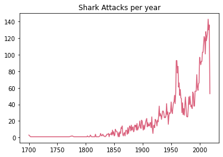

```python
years_values = attacks['Year'].value_counts().sort_index()
years_values.plot(title="Shark Attacks per year", color='#DA627D')
```

### Top 5 de países con más ataques

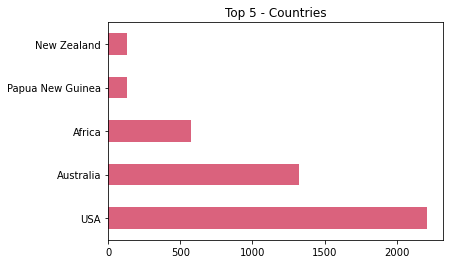

```python
top5_country = attacks['Country'].value_counts().sort_values(ascending=False).head()
top5_country.plot(kind='barh', title="Top 5 - Countries", color='#DA627D')
```

### Top 5 de actividades más peligrosas

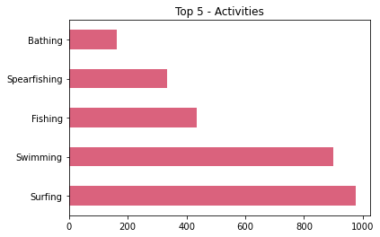

```python
top5_activity = attacks.Activity[attacks['Activity'] != 'Unknown'].value_counts().sort_values(ascending=False).head()
top5_activity.plot(kind='barh', title="Top 5 - Activities", color='#DA627D')
```

### Sexo de las víctimas

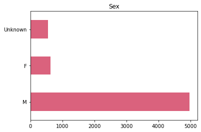

```python
attacks['Sex'].value_counts().sort_values(ascending=False).plot(kind='barh', title="Sex", color='#DA627D')
```

### Mortalidad del ataque

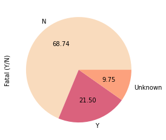

```python
attacks['Fatal (Y/N)'].value_counts().sort_values(ascending=False).plot(kind='pie', colors=['#F9DBBD', '#DA627D', '#FCA17D'], autopct='%.2f')
```

## Conclusion

Basándonos en los datos recogidos desde 1700 hasta la actualidad, podemos concluir que:

1. Un gran número de los ataques reportados sucedieron en la primera y segunda década de los 2000
2. Estados Unidos es el país con más ataques de tiburón reportados
3. El surf es la actividad con más riesgo a sufrir un ataque de tiburón
4. La gran mayoría de las víctimas son hombres
5. Casi el 70% de los casos reportados no fueron mortales